# ggplot2 Package

#### **3-2-1-1. 산점도와 회귀직선**

- 산점도만으로 두 변수의 관계를 파악하는 것보다 회귀직선이나 비모수 회귀곡선 등을 추가하는 것이 훨씬 더 효과적일 수 있다.
  - 회귀직선의 추가는 함수 `geom_smooth()`에 선형회귀모형을 의미하는 옵션 `method = "lm"`을 지정하면 된다.
  - 비모수 회귀곡선의 추가는 함수 `geom_smooth()`에 국소회귀곡선을 의미하는 옵션 `method = "loess"`을 지정하면 된다.

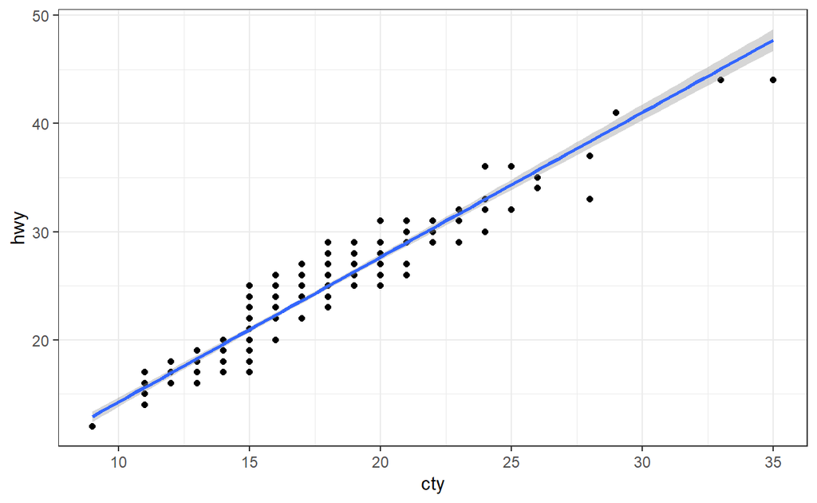

[output not shown]

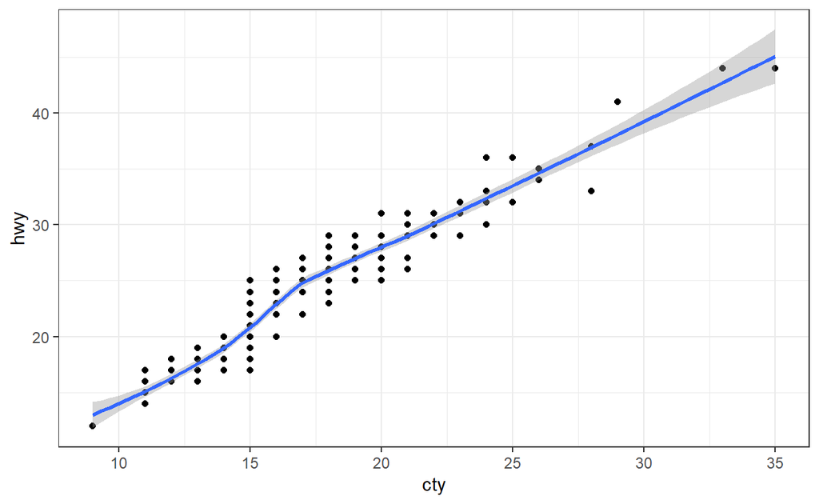

```
# 국소회귀곡선곡선
p1 + geom_smooth(method = "loess")
```

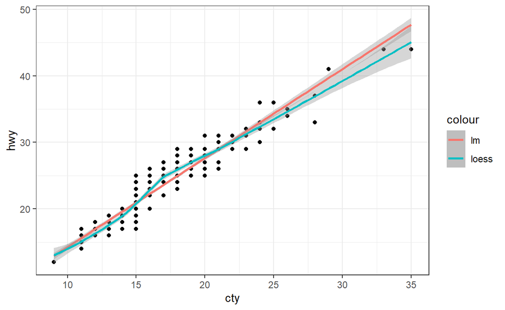

```
# 선형회귀모형과 국소회귀곡선을 함께께
p1 +
  geom_smooth(aes(color = "lm"), method = "lm") +
  geom_smooth(aes(color = "loess"), method = "loess")
```

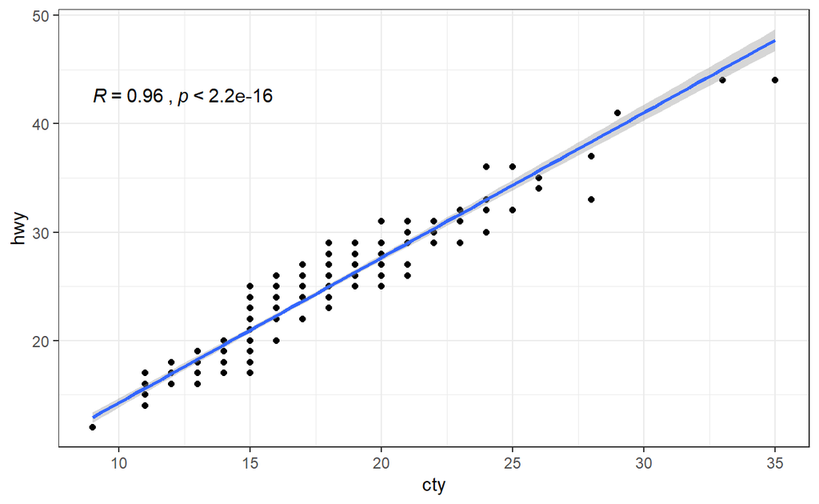

```
pacman::p_load("ggpubr")                                                # For stat_cor()

p1 + geom_smooth(method = "lm") +
  stat_cor(method = "pearson",                                          # 상관분석 방법법
           aes(label = paste(..r.label.., ..p.label.., sep = "~`,`~")), # r.label = R, rr.label = R^2, p.label = p-value
           show.legend = FALSE)
```

`Caution!` 함수 `stat_cor()`를 통해 두 변수 간의 상관계수와 $p$값을 계산할 수 있다. 자세한 옵션은 [여기](https://www.rdocumentation.org/packages/ggpubr/versions/0.4.0/topics/stat_cor)를 참고한다.

#### **3-2-1-2. 산점도와 상자 그림**

- Package `ggExtra`에 내장된 함수 `ggMarginal()`은 산점도 그래프와 함께 주변 분포를 다양한 형태로 나타내는 데 유용한 함수이다.

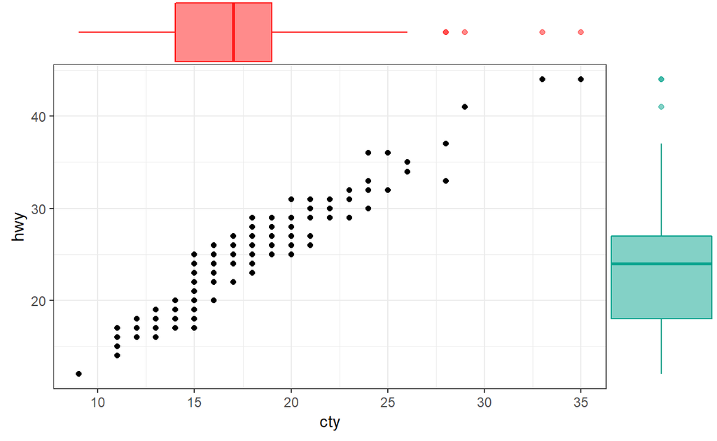

[output not shown]

#### **3-2-1-3. 산점도와 바이올린 그림**

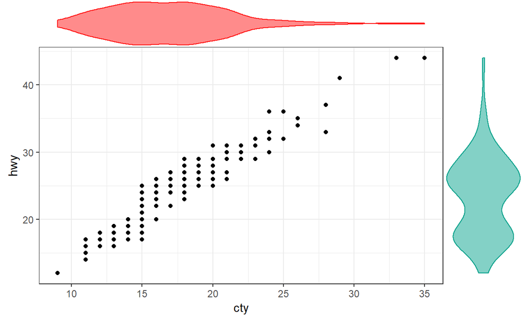

[output not shown]

#### **3-2-1-4. 산점도와 히스토그램**

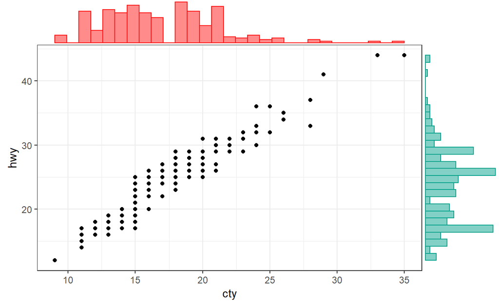

[output not shown]

#### **3-2-1-5. 산점도와 확률밀도함수 그래프**

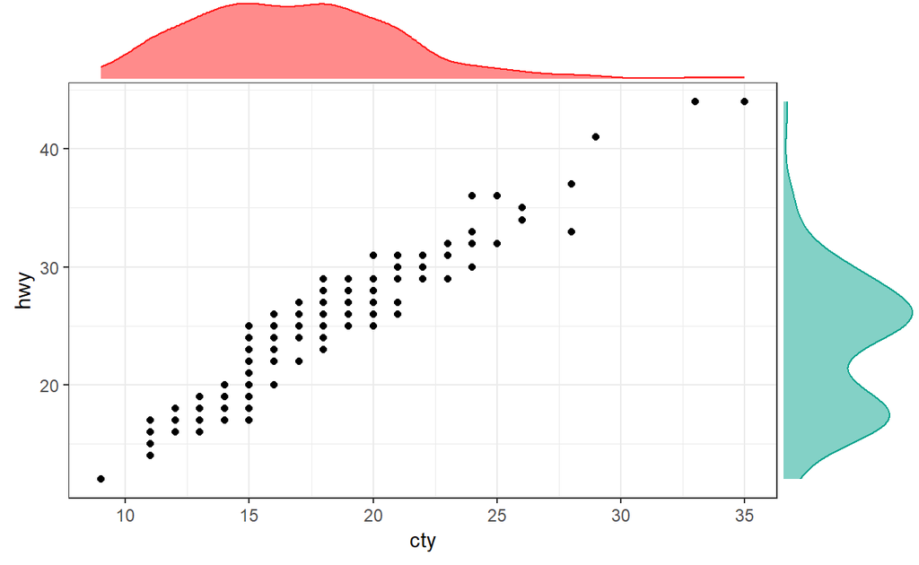

[output not shown]

### **3-2-2. 2D 히스토그램**

- 대규모 데이터를 대상으로 작성된 산점도는 점들이 심하게 겹쳐져서 데이터의 분포를 알아보기 어려운 상황이 발생한다.
- 이러한 문제점을 해결하기 위해 대안으로 제시하는 방법은 함수 `geom_bin2d()`를 통해 2D 히스토그램을 나타내는 것이다.
- 2D 히스토그램은 XY축으로 형성된 2차원 공간을 직사각형의 영역으로 나누고, 각 영역에 속한 데이터의 개수를 색으로 나타내는 그래프이다.

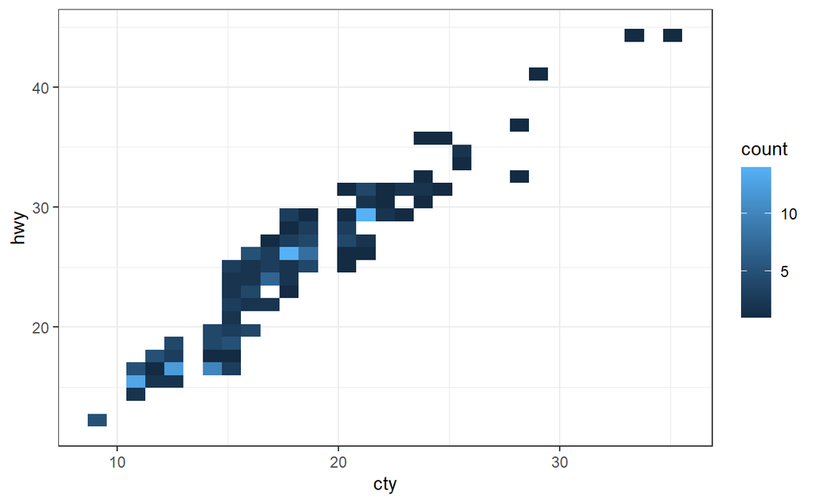

```
ggplot(data, aes(x = cty, y = hwy)) +
  geom_bin2d() +
  theme_bw()
```

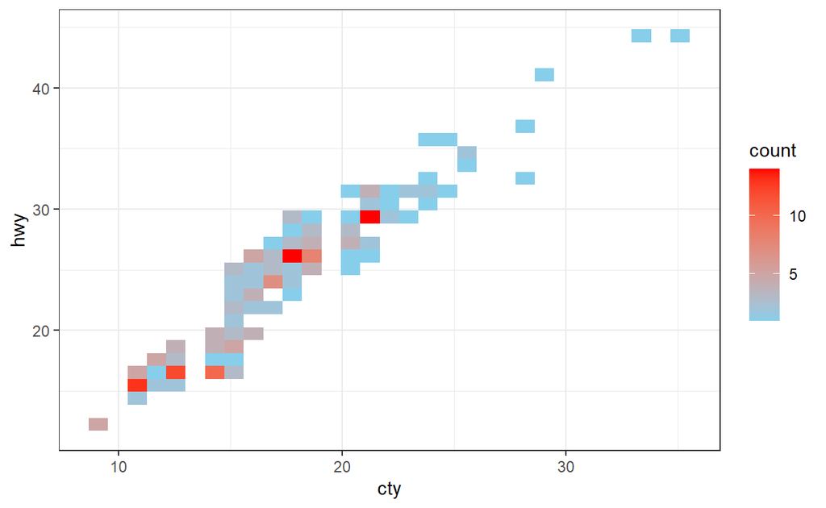

```
ggplot(data, aes(x = cty, y = hwy)) +
  geom_bin2d() +
  scale_fill_gradient(low = "skyblue", high = "red") +
  theme_bw()
```

`Caution!` 함수 `scale_fill_gradient()`을 통해 원하는 색깔을 지정할 수 있다.

### **3-2-3. 이차원 결합확률밀도**

- 두 연속형 변수의 관계를 탐색할 때 두 변수의 결합확률밀도를 추정한 그래프가 큰 역할을 할 수 있다.
- 결합확률밀도함수는 함수 `geom_density_2d()`를 통해 작성할 수 있다.

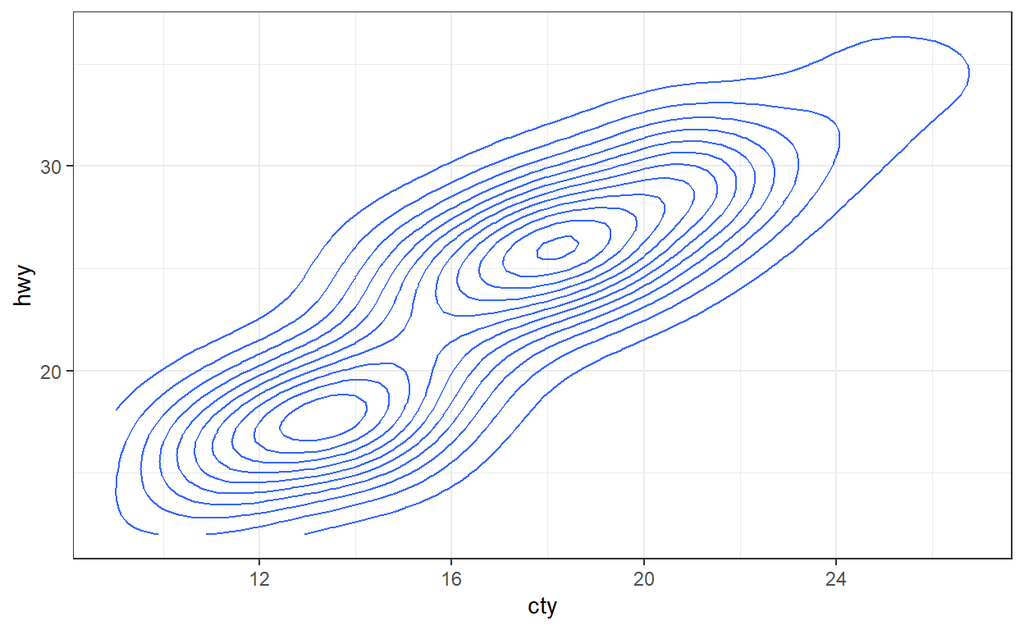

```
ggplot(data, aes(x = cty, y = hwy)) +
  geom_density_2d() +
  theme_bw()
```

`Caution!` 등고선 그래프는 3차원 자료를 2차원 공간에 표시한 것으로 확률밀도가 같은 영역을 선으로 연결하여 그린 그래프다. 각 등고선에 적절한 라벨이 붙어 있어야 확률밀도가 높은 지역과 낮은 지역을 구분할 수 있지만, 라벨을 일일이 확인하여 높이를 구분하는 작업은 번거롭고 부정확할 수 밖에 없다. 대안으로 제시되는 방법은 등고선의 높이를 색으로 구분하는 것이다. 시각적 요소 `color = stat(level)`로 매핑하여 선의 색깔을 구분시킬수 있으며, 함수 `scale_color_gradient()`를 이용하여 색깔의 변화를 조정할 수도 있다.

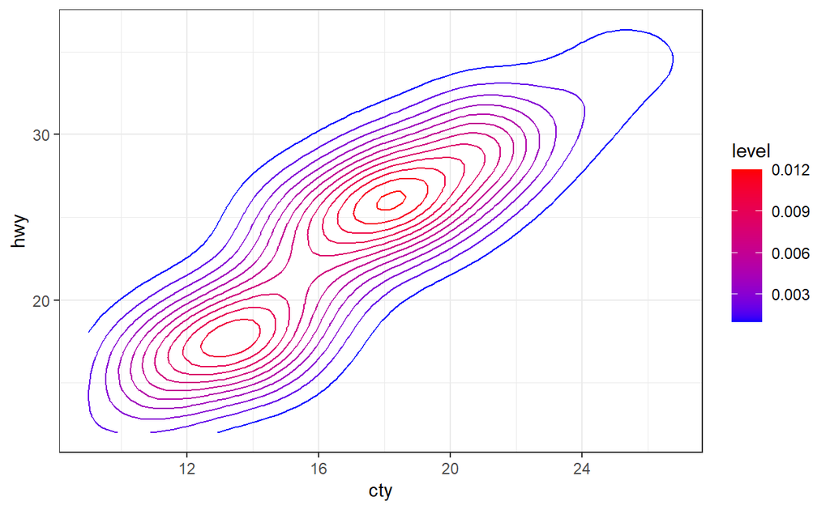

```
ggplot(data, aes(x = cty, y = hwy)) +
  geom_density_2d(aes(color = stat(level))) +
  scale_color_gradient(low = "blue", high = "red") +
  theme_bw()
```

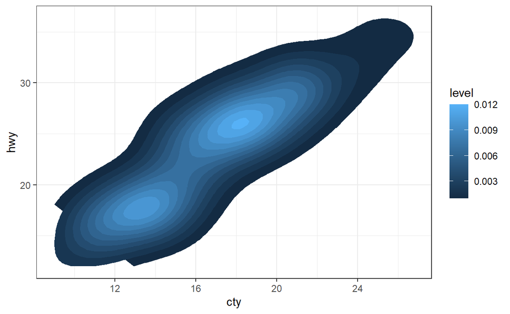

```
ggplot(data, aes(x = cty, y = hwy)) +
  stat_density_2d(aes(fill = stat(level)), geom = "polygon") +
  theme_bw()
```

`Caution!` 등고선을 색으로 구분하는 것보다 높이가 같은 영역을 구분된 색으로 채우는 것이 더 효율적일 수 있다. 작성 방법은 함수 `stat_density_2d()`를 사용하여 옵션 `geom = "polygon"`을 지정하고, 시각적 요소 `fill = stat(level)`을 매핑하는 것이다.

### **3-2-4. 산점도 행렬**

- 산점도 행렬은 여러 변수로 이루어진 자료에서 두 변수끼리 짝을 지어 작성된 산점도를 행렬의 형태로 배열하여 하나의 그래프로 함께 나타낸 그래프이다.
- 복잡하고 어려운 문제를 간단하고 명확하게 해결할 수 있도록 도와주는 뛰어난 그래프라고 할 수 있다.
- 산점도 행렬은 Package `GGally`에 내장된 함수 `ggpairs()`로 작성할 수 있다.

```
pacman::p_load("GGally")

scat_df <- data %>%
  select_if(is.numeric)                                          # 수치형 변수만 선택택
scat_df
```

```
# A tibble: 234 x 5
   displ  year   cyl   cty   hwy
   <dbl> <int> <int> <int> <int>
 1   1.8  1999     4    18    29
 2   1.8  1999     4    21    29
 3   2    2008     4    20    31
 4   2    2008     4    21    30
 5   2.8  1999     6    16    26
 6   2.8  1999     6    18    26
 7   3.1  2008     6    18    27
 8   1.8  1999     4    18    26
 9   1.8  1999     4    16    25
10   2    2008     4    20    28
# ... with 224 more rows
```

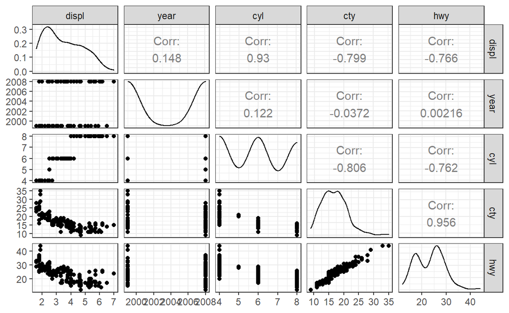

```
ggpairs(scat_df) +
  theme_bw()
```

# **4. 그룹에 따른 연속형 변수 탐색**

- 어느 한 연속형 변수의 분포가 어떤 요인으로 구분되는 그룹마다 다르다면, 그것은 곧 그룹 변수가 연속형 변수에 통계적으로 유의한 영향을 미치고 있다고 해석될 수 있다.
- 그룹별로 분포를 비교하고자 할 때 함수 `facet_wrap()` 또는 `facet_grid()`를 이용할 수 있다.
- 다른 방법으로는 그룹별 그래프를 겹치게 작성하는 것이다.
  - 하나의 그래프에서 비교하는 것이므로 의미있는 비교가 될 수 있을 것이다.

## **4-1. 지터 그래프**

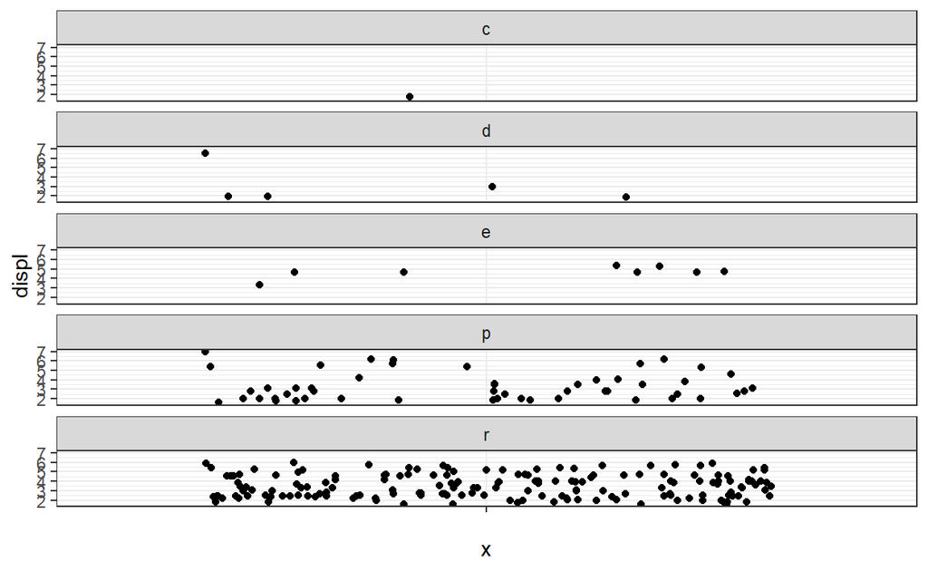

[output not shown]

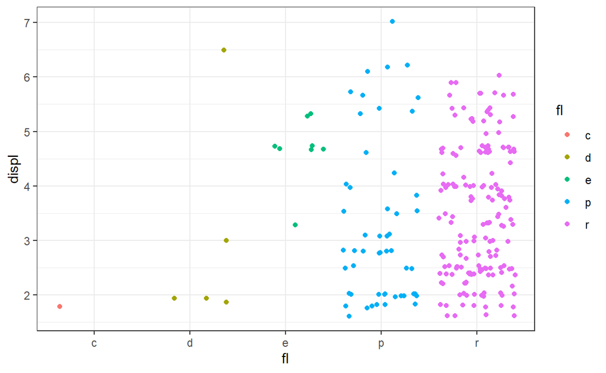

```
# 변수 fl에 따른 변수 displ의 지터 그래프(하나의 그래프로 작성)
ggplot(data, aes(x = fl, y = displ, color = fl)) +
  geom_jitter() +
  theme_bw()
```

## **4-2. 상자 그림**

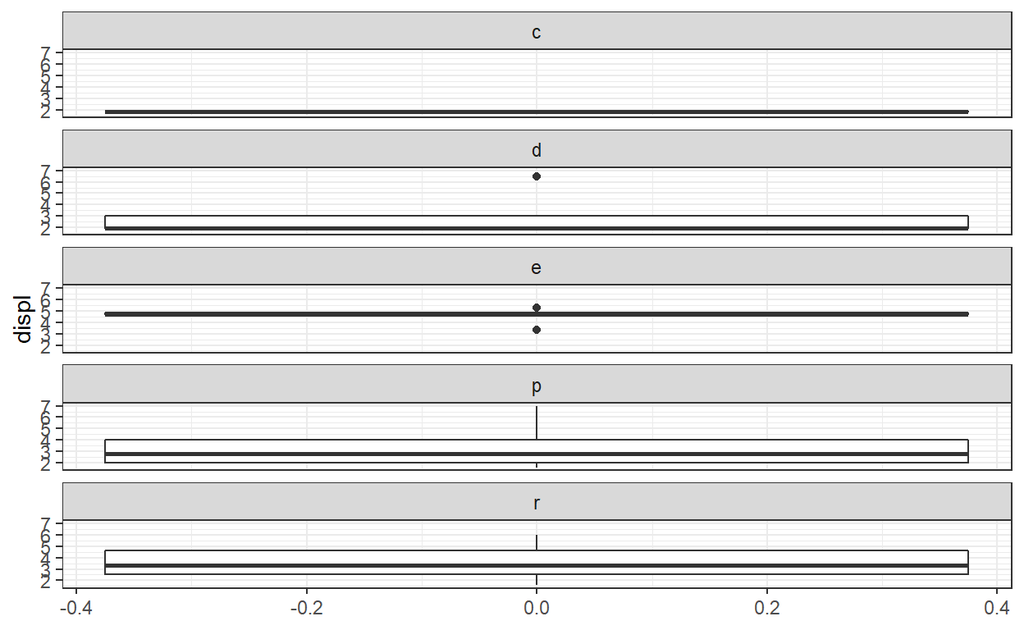

```
# 변수 fl에 따른 변수 displ의 상자 그림(함수 facet_wrap 이용))
ggplot(data, aes(y = displ)) +
  geom_boxplot() +
  facet_wrap(~fl, ncol = 1) +
  theme_bw()
```

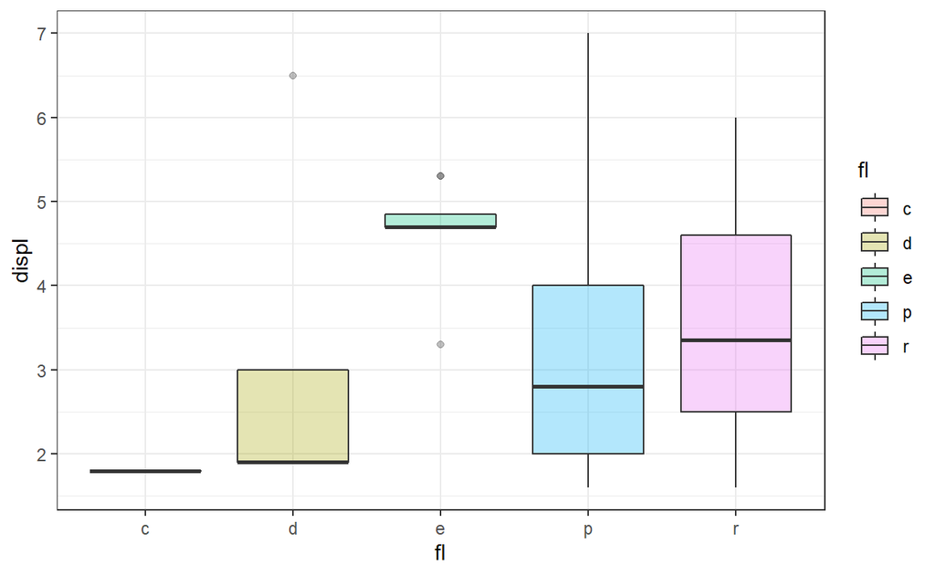

```
# 변수 fl에 따른 변수 displ의 상자 그림(하나의 그래프로 작성)성)
ggplot(data, aes(x = fl, y = displ, fill = fl)) +
  geom_boxplot(alpha = 0.3) +
  theme_bw()
```

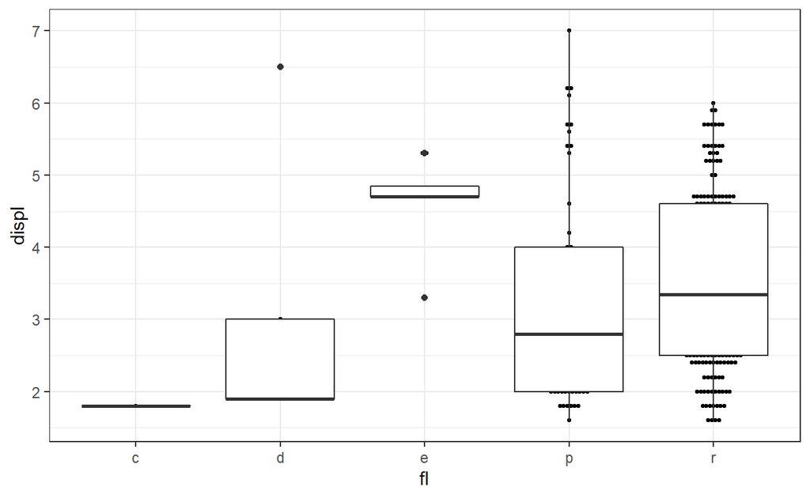

```
# 변수 fl에 따른 변수 displ의 상자 그림과 점 그래프그래프
ggplot(data, aes(x = fl, y = displ)) +
  geom_dotplot(binaxis = "y",                          # 구간 설정 대상이 되는 축축
               binwidth = 0.05,                        # 점 크기
               stackdir = "center") +                  # 점을 쌓아 가는 방향
  geom_boxplot() +
  theme_bw()
```

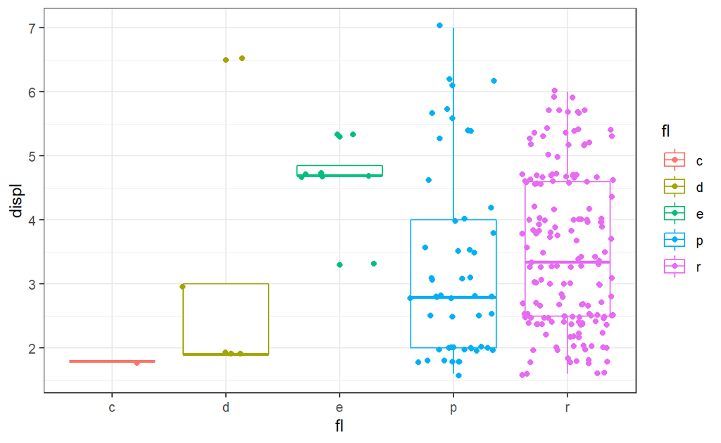

```
# 변수 fl에 따른 변수 displ의 상자 그림과 지터 그래프프
ggplot(data, aes(x = fl, y = displ, color = fl)) +
  geom_boxplot() +
  geom_jitter() +
  theme_bw()
```

## **4-3. 바이올린 그림**

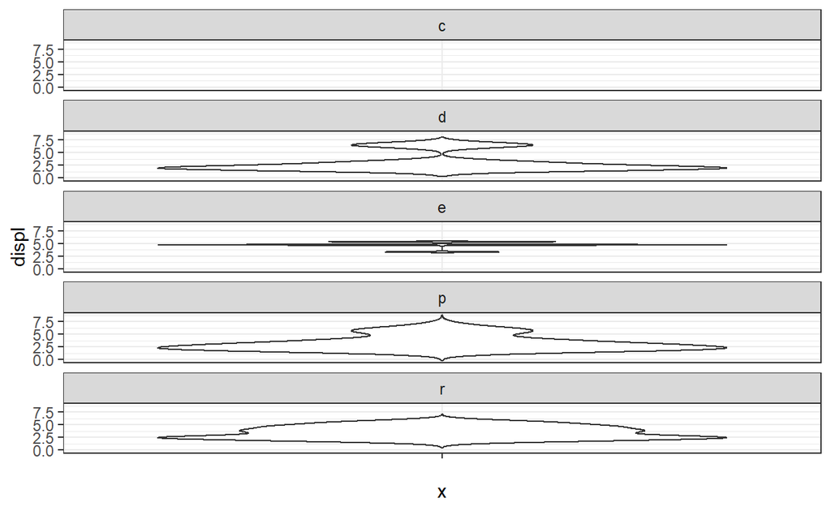

```
# 변수 fl에 따른 변수 displ의 바이올린 그림(함수 facet_wrap 이용)용)
ggplot(data, aes(x = "", y = displ)) +
  geom_violin(trim = FALSE) +
  facet_wrap(~fl, ncol = 1) +
  theme_bw()
```

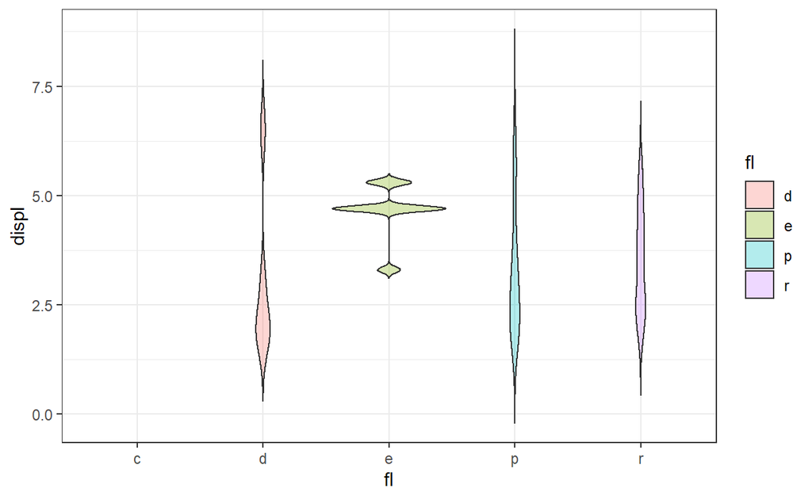

```
# 변수 fl에 따른 변수 displ의 바이올린 그림(하나의 그래프로 작성)작성)
ggplot(data, aes(x = fl, y = displ, fill = fl)) +
  geom_violin(trim = FALSE, alpha = 0.3) +
  theme_bw()
```

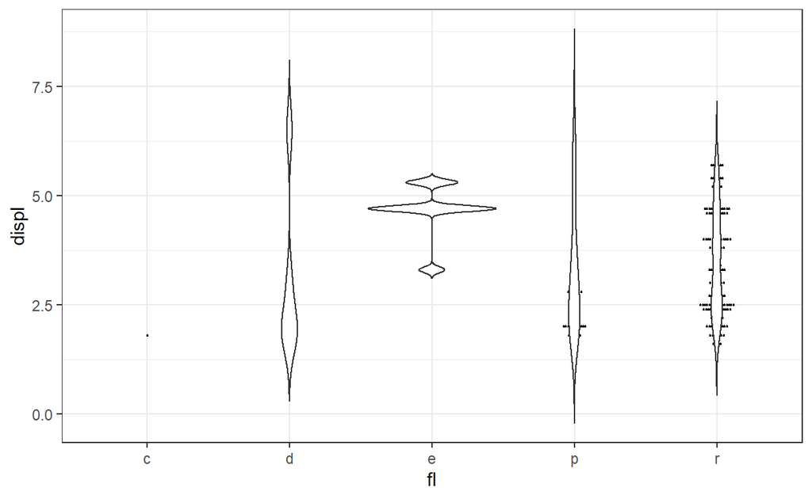

```
# 변수 fl에 따른 변수 displ의 바이올린 그림과 점 그래프 그래프
ggplot(data, aes(x = fl, y = displ)) +
  geom_dotplot(binaxis = "y",                          # 구간 설정 대상이 되는 축축
               binwidth = 0.05,                        # 점 크기
               stackdir = "center") +                  # 점을 쌓아 가는 방향
  geom_violin(trim = FALSE) +
  theme_bw()
```

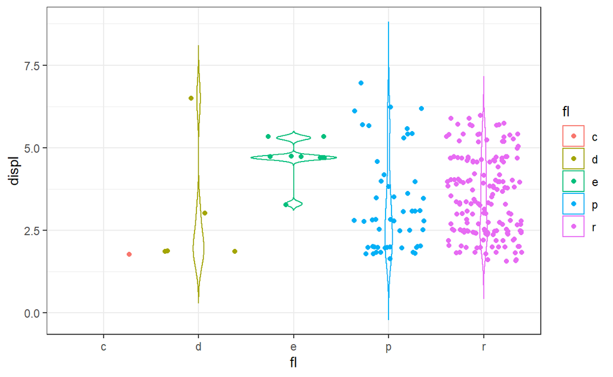

```
# 변수 fl에 따른 변수 displ의 바이올린 그림과 지터 그래프래프
ggplot(data, aes(x = fl, y = displ, color = fl)) +
  geom_violin(trim = FALSE) +
  geom_jitter() +
  theme_bw()
```

## **4-4. 히스토그램**

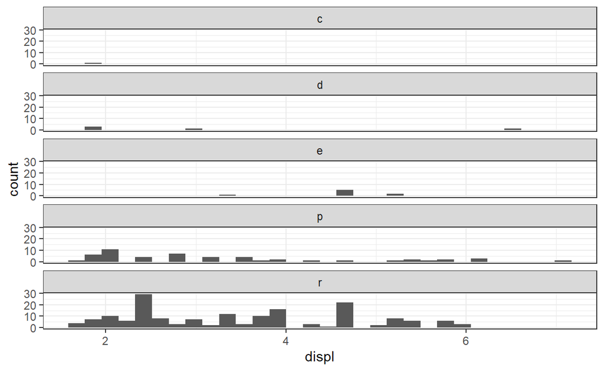

```
# 변수 fl에 따른 변수 displ의 히스토그램(함수 facet_wrap 이용))
ggplot(data, aes(x = displ)) +
  geom_histogram() +
  facet_wrap(~fl, ncol = 1) +
  theme_bw()
```

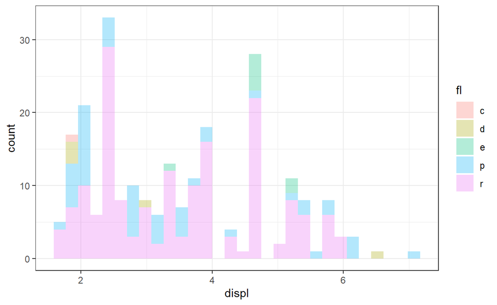

```
# 변수 fl에 따른 변수 displ의 히스토그램(겹쳐서 작성)작성)
ggplot(data, aes(x = displ, fill = fl)) +
  geom_histogram(alpha = 0.3) +
  theme_bw()
```

## **4-5. 확률밀도함수**

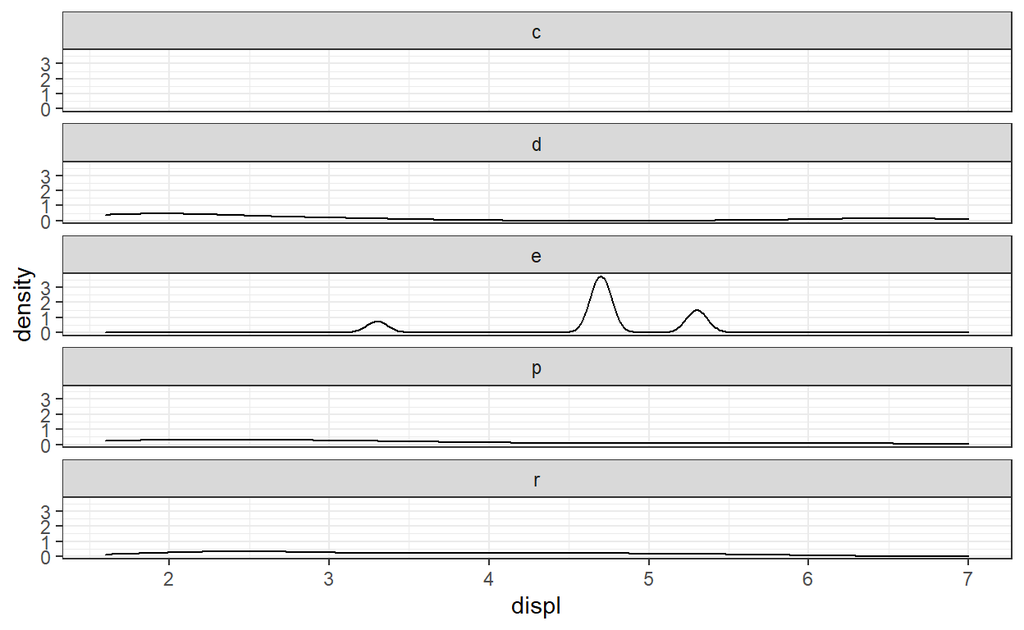

```
# 변수 fl에 따른 변수 displ의 확률밀도함수(함수 facet_wrap 이용))
ggplot(data, aes(x = displ)) +
  geom_density() +
  facet_wrap(~fl, ncol = 1) +
  theme_bw()
```

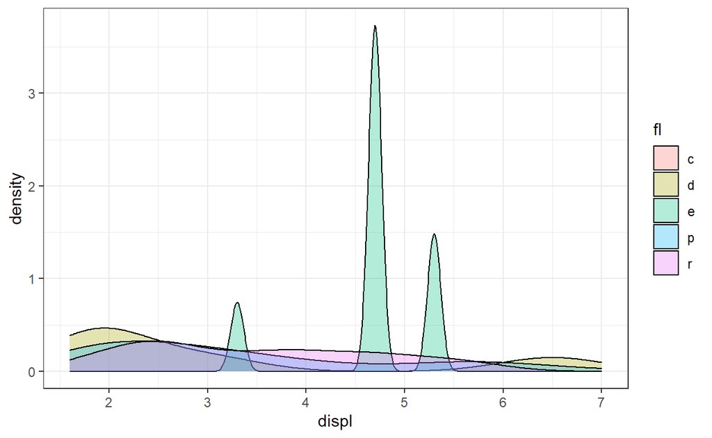

```
# 변수 fl에 따른 변수 displ의 확률밀도함수(겹쳐서 작성)작성)
ggplot(data, aes(x = displ, fill = fl)) +
  geom_density(alpha = 0.3) +
  theme_bw()
```